# Bootcamp worksheet

Axel Barlow & Johanna Paijmans

2026

## Unix-like systems and bash

### 1. Logging on to the Falcon Supercomputer

Prerequisites

- Consult Falcon documentation from Ade Fewings: https://bangoroffice365.sharepoint.com/sites/DigitalServices/SitePages/The-Falcon-Supercomputer.aspx
- Windows users need to download the Windows Subsystem for Linux (WSL) (other solutions exist)
- Linux and Mac users can just ssh from the terminal

You will interact with four main systems:

- **COGS** – The account portal where you request and manage your Falcon login (username and password).
  - https://cogs.cf.ac.uk
- **ColdFront** – Normally only PIs need to access ColdFront. The portal where projects, project membership, and compute allocations are managed.
  - https://coldfront.cf.ac.uk
- **Falcon login node** – The HPC login server where you log in and run jobs.
  - `falcon_username@falconlogin.cf.ac.uk`
- **Bangor’s SSH Bastion** – The gateway you must connect through before you can reach Falcon.
  - `bangor_username@ssh.bangor.ac.uk`

Important Note: COGS and ColdFront are reachable directly from the Bangor LAN - e.g. campus managed wired, VPN or via standard Bangor remote access solutions such as the Linux Desktop available through eResearch OnDemand. Also note:

- your bangor_username for the ssh server and falcon_username are different
- bangor_username has your normal password with MFA
- falcon_username password (suggest no special characters) can be set in COGS

```bash
# Linux/Mac/WSL
# Open a terminal
ssh you25usr@ssh.bangor.ac.uk
# enter your bangor password and complete MFA

# from bangor ssh server, log into falcon
ssh b.you25usr@falconlogin.cf.ac.uk

# ! advanced option: all-in-one
ssh -J you25usr@ssh.bangor.ac.uk b.you25usr@falconlogin.cf.ac.uk
```

### 2. Basic bash commands

Unix-like (linux and Mac) generally use a bash shell (or something like it).

“*Bash is a command processor that typically runs in a text window where the user types commands that cause actions. Bash can also read and execute commands from a file, called a shell script. Like most Unix shells, it supports filename globbing (wildcard matching), piping, here documents, command substitution, variables, and control structures for condition-testing and iteration.*”

See https://en.wikipedia.org/wiki/Bash_(Unix_shell)

```bash
# print working directory
pwd

# make directory
mkdir my_directory

# change directory
cd my_directory

# print working directory
pwd

# print something to screen
echo "hello"

# redirect output to file
echo "hello" > hello.txt

# list contents of directory
ls

# help menu
ls --help

# view contents of file
cat
less
head

# print something else to file
echo "hello2" > hello.txt
echo "hello" > hello.txt
echo "hello2" >> hello.txt

# count lines and characters
wc -l
wc -c

# search for content in files
grep --help
grep "2" hello.txt

# pipes
grep "2" hello.txt | wc -l

# deleting (CAREFUL!!!)
rm hello.txt

# let's make some more files
yes hello | head -n 100 > my_file1.txt
yes goodbye | head -n 100 > my_file2.txt

# wildcards
cat my_file* > my_combined_file.txt

# a note on file extensions
mv my_combined_file2.txt my_combined_file2.mp3
mv my_combined_file2.txt my_combined_file2

# deleting with wildcards (VERY CAREFUL!!!)
rm my*

# Download file from internet: e.g. NCBI
wget https://ftp.ncbi.nlm.nih.gov/genomes/all/GCF/964/194/415/GCF_964194415.1_rVipBer3.hap1.1/GCF_964194415.1_rVipBer3.hap1.1_genomic.fna.gz

# Note file is compressed with gzip compression
# view contents without unzipping
zcat GCF_964194415.1_rVipBer3.hap1.1_genomic.fna.gz | less

# uncompress
gunzip GCF_964194415.1_rVipBer3.hap1.1_genomic.fna.gz
# note you can compress with the command gzip

# log off
exit
```

### 3. Your turn :)

- Count number of scaffolds in the adder genome
- Print scaffold names to a file
- Print only scaffold names 10 to 20 to a file
- Count the number of bases in the first line of DNA sequence (i.e. line 2)
- Work out the genome size (don’t worry about newline characters in your base counts for now)
- If you are finished early, you can find a genome of your choice to play around with
- Or… advanced! look at setting up a jump host for 1-step log on and easier data transfer to your local PC: https://bangoroffice365.sharepoint.com/sites/DigitalServices/SitePages/eResearch_Connecting-to-eResearch-Resources.aspx

### 4. Bash scripts

- Bash scripts allow sets of commands to be executed in an automated fashion
- Files contain bash scripts are given the extension `.sh` by convention
- fist line is the bash **shebang**, it instructs the system to parse the file using `bash` (as opposed to `python, perl, R`, etc.)
- lines starting `#` are comments
- commands are executed from top to bottom

```bash
#!/bin/bash

# let's make some files
yes hello | head -n 100 > my_file1.txt
yes goodbye | head -n 100 > my_file2.txt

# combine files
cat my_file* > my_combined_file.txt

echo "job finished"
```

#### A note on text editors

- never (ever) use a word processor
- plain text editor (many available)
- includes terminal plain text editors
- be careful windows people :)
- example: `vim`

```bash
# open file
vim my_script.sh

# enter insert mode
i

# do stuff ######################################

# exit insert mode
[ESC]

# write changes to file
:w

# quit
:q
```

#### Executing bash scripts

```bash
sh my_script.sh
```

### 5. Your turn :)

- Generate the `bash` script described above and execute
- try modifying the script, for example to delete the intermediary files my_file1.txt and my_file2.txt
- If you are finished early, think what other functions you could add to your script. For example lines counts reported to the terminal or saved in a file

### 6. Variables

- In `bash`, variables can be used to store data in memory
- Works exactly like objects in `R`
- After they are defined, variables can be recalled using `$`
- anything entered after the script call becomes variables `$1, $2, $3`, etc.
- Or they can be defined in the script `variable=value`

```bash
#!/bin/bash

# script makes lists of 2 words, which can be entered when the script is called
# $count controls the length of the list
# call the script like:
# sh my_script.sh hello goodbye

# declare variables
count=100

# main script

# let's make some files
yes $1 | head -n $count > my_file1.txt
yes $2 | head -n $count > my_file2.txt

# combine files
cat my_file* > my_combined_file.txt

echo "job finished"
```

### 7. Loops

- Loops are quite an advanced feature, but extremely useful
- here we look at a basic while loop with a counter

```bash
#!/bin/bash

x=0

while [ $x -lt 10 ]; do
  echo The counter is $x
  let x=x+1
done
```

## `markdown` and `Rmarkdown` in `Rstudio`

At this stage, you may be taking notes on commands and results in some way. We suggest `markdown` is the best option for this. It is a simple text format that allows you to combine text, code and results in a single document, and knit to html to view in an internet browser.

`Rmarkdown` is an one implementation of markdown for use within `Rstudio`. An `Rmarkdown` document is written in markdown and contains chunks of embedded `R` code, which can be executed and results knitted to the html.

- In Rstudio select File > New File > R Markdown
- Below is a simple example that we will work though

```bash
# this is an example yaml header that goes at the top of the document
---
title: "R markdown example"
author: "Axel Barlow"
date: "2023-10-31"
output:
  html_document:
    keep_md: true
---
```

The setup chunk is a special code chunk that is executed at the start of the document. It is used to set options for the document and load libraries.

```r
knitr::opts_chunk$set(echo = TRUE)
```

### 1. Basic text formatting

```r
## Header 1

### Header 2

#### Header 3

You can just write stuff like this

- list1
- list2
  - sublist 1
  - sublist 2

1. Numbered list1
2. Numbered list2

**here is bold**

*here is italic*

`this is inline code`

## Tables

Subject|Emotion|Object
--|--|--
I|hate|Powerpoint
I|love|Rmarkdown
```

### 2. `R` code chunk

````r
# ```{r, echo=TRUE, eval=TRUE}
# here is some R code that is executed
1+1
# ```
````

## `bash` code chunk (not exectuted)

````r
# ```bash
echo "hello"
# ```
````

## Supercomputing Wales and slurm

### 1. Filesystem

```bash
# print working directory
pwd

# list contents of working directory
ls

# move up one level in hierarchy
cd ..

# print working directory
pwd

# list contents of working directory
ls

# move to root directory
cd /

# list contents of working directory
ls

# Go home
cd ~
```

### 2. Copying files

```bash
# copying files
cp <source> <destination_file>
cp sheep.txt bla/sheep_in_bla.txt

# on hawk: make a small file
echo "scp'ing is awesome!" > copy.txt

# check the small file
cat copy.txt

# open a new terminal from your local PC & log into the ssh jump host
ssh you25usr@ssh.bangor.ac.uk

# copy the file from falcon to bangor ssh server
scp b.you25usr@falconlogin.cf.ac.uk:/home/b.you25usr/copy.txt .

# log out of bangor ssh server
exit

# copy the file from bangor ssh server to your local PC
scp you25usr@ssh.bangor.ac.uk:/home/people/you25usr/copy.txt .

# for WSL users: if you move the file to your Windows filesystem, you can edit in Notepad etc
# your windows filesystem can be found in the WSL in the following path:
/mnt/c/Users/your_windows_username/


# !Advanced! all-in-one
scp -o ProxyJump=you25usr@ssh.bangor.ac.uk b.you25usr@falconlogin.cf.ac.uk:/home/b.you25usr/copy.txt .
```

## Paths of glory game :)

```bash
# start in your home
cd

# Copy the contents of this file:
/scratch/scw2141/oooooo/its/such/a/long/filepatch/paths_of_glory.txt

# To a file named with your name, here:
/scratch/scw2141/and/did/he/use/caPITAls/what/a/masochist/
```

### 3. Modules

```bash
# module searching
module avail
module avail R

# module load
module load R/4.2.0

# module unload
module purge
```

### 4. Slurm

```bash
# You are currently using the log in node.
# Do not run resource-intensive jobs on the log in node!

# use slurm to open an active bash shell on a compute node
srun --nodes=1 --ntasks=4 --mem=4G --time=0-00:20 --pty /bin/bash

# the queue
squeue
squeue -u username

# do something resource intensive
module load pigz
pigz -p 4 ASM28112v4_HiC.fasta

# exit
exit

# check efficiency
seff jobid
```

### 5. Slurm scripts

- Running a live terminal is not very convenient
- We need a way of submitting jobs to the queue: `slurm` job script
- It’s just a bash script, with additional options passed to `slurm` using `#SBATCH`

```bash
#!/bin/bash --login
###
#job name
#SBATCH --job-name=example
#job stdout file
#SBATCH --output=/path/to/dir/example%J
#job stderr file
#SBATCH --error=/path/to/dir/example_err%J
#maximum job time in D-HH:MM
#SBATCH --time=0-00:01
#number of nodes
#SBATCH --nodes=1
#number of parallel processes (tasks)
#SBATCH --ntasks=1
#memory in Gb
#SBATCH --mem=1G

echo hello > hello.txt
```

```bash
# submit to queue
sbatch job_script.sh
```

#### For people who have multiple accounts

- If you have multiple accounts on SCWales, the command above will throw an error
- You can specify the acount at the command line, or include in the slurm script

```bash
#command line
sbatch account=scw1234 job_script.sh

# or include the following SBATCH in the script

#assign account
#SBATCH account=scw1234
```

### 5. Your turn :)

- make 2 new directories in your `home`: `my_slurm_scripts` and `output_logs`
- make a copy of the `slurm` script in `./my_slurm_scripts`
- Direct stdout and error messages to `./output_logs`
- Specify 1 node, 4 cpus, 8Gb RAM, 1 hour
- Submit job to queue

**Next**

## Population genomics: population structure and heterozygosity

Our shared project directory is `/scratch/SCWF00251/`

### 1. Tour and `BEARCAVE`

```bash
# enter project directory
cd /scratch/SCWF00251/

# view directories
ll

# bams
ll BEARCAVE2/mappedrVipBer3_chr6/

# ref genome
ll BEARCAVE2/refgenomes/rVipBer3_chr6/

# look at coverage
module load SAMtools
samtools coverage BEARCAVE2/mappedrVipBer3_chr6/adder0X_XXX_chr6.bam | head -2
```

## Intro to basic `R` commands

Download the lizard_data.txt file to your working directory (use right-click “Save link as…”):

[Download lizard_data.txt](https://raw.githubusercontent.com/drabarlow/bioinformatics_bootcamp/main/assets/data/lizard_data.txt)

```r
# R is just a big calculator
1+1

# make an object
my_sum <- 1+1

# vectors
my_vec <- c(1,2,3,4)

# functions
length(my_vec)

# plotting
my_vec2 <- c(1,2,3,4) # geenrate data
plot(my_vec, my_vec2)
plot(c(1,2,3,4), c(4,3,2,1))

# sample from a normal distribution
rnorm(500, 10, 1)

# histogram
hist(rnorm(500, 10, 1))

# read in data as a dataframe
my_liz <- read.table("lizard_data.txt", header=TRUE)

# isolate svl data
my_liz$svl

# and we can make this into a self-contained script too...
# ...and also run this on the SCW
```

### Your turn

- Draw a histogram of lizard body width
- Draw a scatterplot of svl vs width
- Calculate means and standard deviations for each variable
- If you have finished early, try out ways to make your plots more attractive
- Also if you finished early, copy the contents of `/scratch/scw2141/addeRs/` to you home directory and execute the `lizards.R` script on falcon
- and write a slurm script to submit it to the queue

## TODO Rmarkdown

Create code chunks from the above code & knit output document

## Pretty maps

download the following 3 files to your working directory (use right-click “Save link as…”):

[Download adder_distribution.shx](https://raw.githubusercontent.com/drabarlow/bioinformatics_bootcamp/main/assets/data/adder_distribution.shx)

[Download adder_distribution.shp](https://raw.githubusercontent.com/drabarlow/bioinformatics_bootcamp/main/assets/data/adder_distribution.shp)

[Download adder_info.txt](https://raw.githubusercontent.com/drabarlow/bioinformatics_bootcamp/main/assets/data/adder_info.txt)

```r
# read in the data
adders <- read.table("adder_info.txt", header=T, sep='\t')

# retrieve map
map <- getMap(resolution = "low")

# load libraries
library(rworldmap)

# plot simple map
plot(map, col="grey", border=NA)

# load libraries
library(sf)

# add IUCN distribution as SHP file on the map
iucn <- st_read("adder_distribution.shx")
plot(st_geometry(iucn), add=TRUE, border=NA, col="slategrey")

# add samples
points(adders$lon,adders$lat)
```

### your turn

- crop the map to the region of interest using xlim and ylim in the `plot()` function
- colour the points by locality (adders$col)
- create your own colours that are colourblind friendly without changing the input file
- change the symbols / sizes
- make this into a self contained script
- if you have finished early, try to make the script save your map as pdf
- Also if you finished early, execute your map making script on hawk (files are in `/scratch/scw2141/addeRs/`)
- and you can even write a slurm script & submit to queue

## Population genetics

You can use your own angsd output files or the ones here:

[Download bamlist_ingroup.covMat](https://raw.githubusercontent.com/drabarlow/bioinformatics_bootcamp/main/assets/data/bamlist_ingroup.covMat)

[Download bamlist_outgroup.ibsMat](https://raw.githubusercontent.com/drabarlow/bioinformatics_bootcamp/main/assets/data/bamlist_outgroup.ibsMat)

[Download adder01_het.window.sfs](https://raw.githubusercontent.com/drabarlow/bioinformatics_bootcamp/main/assets/data/adder01_het.window.sfs)

### 1. PCA

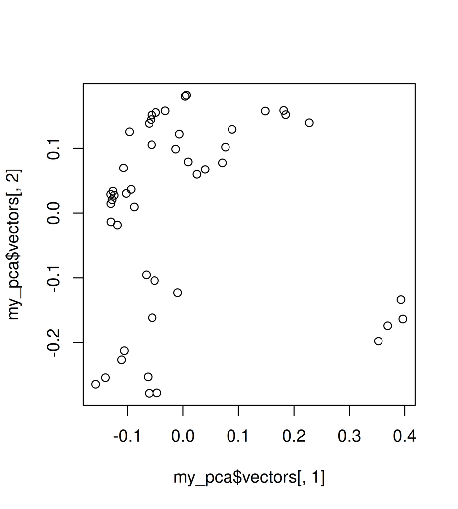

```r
# read in covariance matrix
my_cov <- as.matrix(read.table("./assets/data/bamlist_ingroup.covMat"))

# do PCA
my_pca <- eigen(my_cov)

# plot
plot(my_pca$vectors[,1], my_pca$vectors[,2])
```

### 2. NJ tree

```r
# we use the ape library
library(ape)

# read in matrix
my_mat <- as.matrix(read.table("./assets/data/bamlist_outgroup.ibsMat"))

# compute tree
my_tree <- nj(my_mat)

# plot
my_root <- root(my_tree, outgroup=48)
plot(my_root)
```

[figure not shown]

## Population genomics: genetic diversity

```bash
# set files as variables
input='/scratch/scw2141/BEARCAVE2/mappedberus_chr7/xxx+adderxx_ber_berus_chr7_.xxxxx.bam'
output='adderxx_het'
# We need to specify the ancestral allele, use fasta generated from bosniensis outgroup
bos='/scratch/scw2141/bosniensis_chr7/bosniensis_chr7.fa'

# depth variables
max=20
min=3

# estimate genotype likelihoods
# -i = input file
# -doSaf = per-site allele frequencies
# -GL = genotype likelihood model
# -P = number threads
# -anc = outgroup, to identify ancestral allele
#-minQ,-minMapQ = min base and map quality
# -setMinDepthInd, -setMaxDepthInd = max and min depth filters
angsd -i $input -doSaf 1 -GL 1 -P 10 -anc $bos -out $output -minMapQ 30 -minQ 30 -setMinDepthInd $min -setMaxDepthInd $max -doCounts 1

# calculate sfs
# -nSites = sliding window size
# -P = no threads
realSFS $output.saf.idx -nSites 100000 -P 10 > $output.window.sfs
```

### 3. Heterozygosity

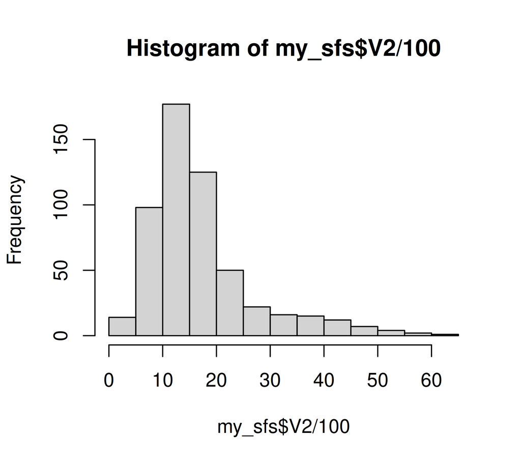

```r
my_sfs <- read.table("./assets/data/adder01_het.window.sfs")
hist(my_sfs$V2/100)
```

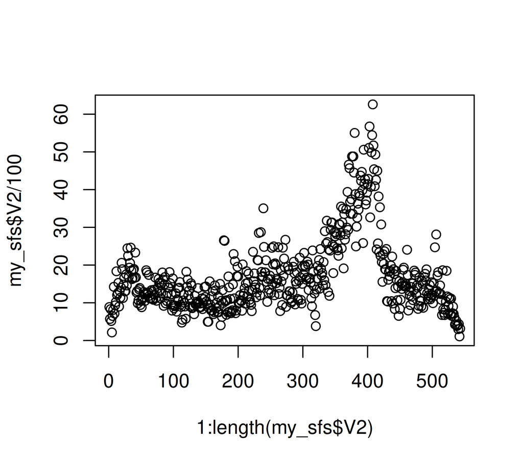

```r
plot(1:length(my_sfs$V2), my_sfs$V2/100)
```

### Your turn

Each plot is in its most basic form. Spend some time trying to improve each one to your liking

[Example script plot.R](https://raw.githubusercontent.com/drabarlow/bioinformatics_bootcamp/main/assets/data/plot.R)

[pdf output my_adder_plot.pdf](https://raw.githubusercontent.com/drabarlow/bioinformatics_bootcamp/main/assets/data/my_adder_plot.pdf)